# Structural Topic Model (STM) for Open Text Analysis

Note: This code uses the example from the **stm** vignette as a starting point. Some cells may take a while to run.

```r
# r setwd - set the working directory
#setwd("/Users/emilyrobitschek/git/ETH/SPUR/stm_projects")
#setwd("/Users/emilyrobitschek/git/ETH/SPUR/densification_project/stm_resources")

# load required packages
library(lda)
library(slam)
library(stm)
library(knitr)
```

## Reading and preparing data in **stm**

Read in the data prepared with the python script pre-processing. Note: the columns and metadata columns (columns_meta) correspond to the spur_survey_response_filtered_df1_for_stm_corrected_imces_v2.csv because of recoded variables, including gender.

```r
columns <- c('id', 'doc', 'frame', 'minority', 'linguistic_minority', 'religious_minority', 'social_class_minority', 'sexual_orientation_minority', 'ethnic_minority', 'national_minority', 'other_minority', 'disabled_minority', 'gender', 'age_numerical', 'income', 'citizenship', 'education', 'political_left_right', 'exp_housing_discrim', 'city_district', 'city_neighborhood', 'prof_situation', 'fear_forced_out', 'seen_landlord_pressure', 'changes_in_community', 'seen_renovations', 'neighborhood_connection', 'respect_rules', 'neighbhorhood_crime', 'env_pollution_impact', 'climate_concern', 'age', 'city', 'country', 'preframe_densifproj_acceptance', 'postframe_densifproj_acceptance', 'densifproj_on_rent', 'densifproj_on_social', 'imce_RentContr', 'imce_InclZon', 'imce_Partic', 'imce_nonProf', 'imce_dens', 'imce_mixUse', 'imce_ClimNeutr')

columns_meta <- c('id', 'frame', 'minority', 'gender', 'age_numerical', 'income', 'citizenship', 'education', 'political_left_right', 'exp_housing_discrim', 'city_district', 'city_neighborhood', 'prof_situation', 'fear_forced_out', 'seen_landlord_pressure', 'changes_in_community', 'seen_renovations', 'neighborhood_connection', 'respect_rules', 'neighbhorhood_crime', 'env_pollution_impact', 'climate_concern', 'age', 'city', 'country', 'preframe_densifproj_acceptance', 'postframe_densifproj_acceptance', 'densifproj_on_rent', 'densifproj_on_social', 'imce_RentContr', 'imce_InclZon', 'imce_Partic', 'imce_nonProf', 'imce_dens', 'imce_mixUse', 'imce_ClimNeutr')

#meta columns to use with spur_survey_response_filtered_df1_for_stm_corrected_imces_v2.csv because of recoded gender variable
columns_meta <- c('id', 'frame', 'minority', 'gender_Female', 'gender_Male', 'gender_Non.binary', 'gender_Prefer.not.to.say','age_numerical', 'income', 'citizenship', 'education', 'political_left_right', 'politics', 'politics_w_extremes', 'exp_housing_discrim', 'city_district', 'city_neighborhood', 'prof_situation', 'fear_forced_out', 'seen_landlord_pressure', 'changes_in_community', 'seen_renovations', 'neighborhood_connection', 'respect_rules', 'neighbhorhood_crime', 'env_pollution_impact', 'climate_concern', 'age', 'city', 'country', 'preframe_densifproj_acceptance', 'postframe_densifproj_acceptance', 'densifproj_on_rent', 'densifproj_on_social', 'imce_RentContr', 'imce_InclZon', 'imce_Partic', 'imce_nonProf', 'imce_dens', 'imce_mixUse', 'imce_ClimNeutr')

survey_data_file <- "data/spur_survey_response_filtered_df1_for_stm_corrected_imces_v2.csv"
surveyFull <- read.csv(survey_data_file)
#summary(surveyFull)
```

Create some of the objects/files for running stm.

We can convert the data to a dataframe format, take a look at the first five documents in long and short format, and save the metadata columns for later filtering if needed.

```r
survey <- data.frame()
survey.fulltext <- surveyFull$doc
survey.shorttext <- substr(survey.fulltext,1,200)
survey.fulltext[1:5]
survey.shorttext[1:5]
survey.meta <- surveyFull[,columns_meta]
survey.meta
```

| id | frame | minority | gender_Female | gender_Male | gender_Non.binary | gender_Prefer.not.to.say | age_numerical | income | citizenship | education | political_left_right | politics | politics_w_extremes | exp_housing_discrim | city_district | city_neighborhood | prof_situation | fear_forced_out | seen_landlord_pressure | changes_in_community | seen_renovations | neighborhood_connection | respect_rules | neighbhorhood_crime | env_pollution_impact | climate_concern | age | city | country | … |
| --- | --- | --- | --- | --- | --- | --- | --- | --- | --- | --- | --- | --- | --- | --- | --- | --- | --- | --- | --- | --- | --- | --- | --- | --- | --- | --- | --- | --- | --- | --- |
| R_10PI5FKTTlId8Ec | other district | 1 | 1 | 0 | 0 | 0 | 20 | 8 | US Naturalization | Master's degree | 5 | conservative | conservative | No | Southwest Side | West Lawn | Not working (disability/illness) | -1 | -1 | 0 | -1 | -2 | 1 | 2 | 6 | 0 | 1 | Chicago | United States | … |
| R_1gduid1fizdQ4d8 | other district | 0 | 0 | 1 | 0 | 0 | 40 | 8 | US Born | Bachelor's degree | 6 | conservative | conservative | No | North Side | North Center | Employed (full-time) | -1 | -1 | 1 | 2 | 2 | 1 | 1 | 9 | 2 | 3 | Chicago | United States | … |
| R_23WCgmyuPAy3b1G | other district | 1 | 1 | 0 | 0 | 0 | 21 | 5 | US Born | Secondary school certificate | 1 | liberal | liberal | Yes | Central, Near North, and Near North Side | Near North Side | Employed (part-time) | -2 | 0 | -1 | 1 | 1 | 0 | 0 | 9 | 2 | 1 | Chicago | United States | … |
| R_1pLEMXp5iJbankG | other district | 1 | 0 | 1 | 0 | 0 | 35 | 6 | US Born | Higher technical examination | 7 | conservative | very conservative | No | North Side | Lincoln Park | Employed (full-time) | 2 | 2 | 2 | 2 | 2 | 2 | 2 | 10 | 0 | 3 | Chicago | United States | … |
| R_2OYEXKWutkzQOmS | other district | 0 | 1 | 0 | 0 | 0 | 20 | 4 | US Born | Secondary school certificate | 1 | liberal | liberal | No | West and Near West Side | Near West Side | Employed (part-time) | 0 | 1 | 2 | 0 | -1 | -1 | -1 | 8 | 2 | 1 | Chicago | United States | … |
| R_2D78ZtjvOL2VauO | other district | 0 | 0 | 1 | 0 | 0 | 56 | 1 | US Born | Higher education entrance qualification | 2 | liberal | liberal | No | South Side | Bridgeport | Not employed (unemployed) | -2 | -1 | -1 | 1 | -1 | 0 | -1 | 4 | 1 | 5 | Chicago | United States | … |
| R_1pxIniAiPx4MXHu | other district | 0 | 1 | 0 | 0 | 0 | 37 | 2 | US Born | Secondary school certificate | 5 | conservative | conservative | No | Southwest Side | Garfield Ridge | Employed (full-time) | 0 | -1 | 0 | 0 | 0 | 0 | 0 | 4 | 1 | 3 | Chicago | United States | … |
| R_2vbHXR2XJtxJNfq | other district | 0 | 1 | 0 | 0 | 0 | 22 | 2 | US Born | Secondary school certificate | 4 | moderate | moderate | No | South Side | South Shore | Employed (part-time) | 1 | 0 | 0 | -1 | 0 | 2 | 1 | 3 | 0 | 1 | Chicago | United States | … |
| R_3kHAhwATe1o0N82 | other district | 1 | 0 | 1 | 0 | 0 | 46 | 9 | US Naturalization | Higher technical examination | 7 | conservative | very conservative | No | Northwest Side | Portage Park | Employed (full-time) | 2 | 2 | 2 | 2 | 2 | 2 | 2 | 10 | 2 | 4 | Chicago | United States | … |
| R_cACHPOld7dnejiF | district | 0 | 0 | 1 | 0 | 0 | 35 | 7 | US Born | Bachelor's degree | 4 | moderate | moderate | No | Far North Side | Rogers Park | Not working (other reason) | -1 | -1 | 1 | 0 | -1 | -1 | -1 | 7 | 1 | 3 | Chicago | United States | … |

[output cut: 990 more lines]

### Preprocessing option 1: within the **stm** package

The *stm* package converts a vector of text and a dataframe of metadata into **stm** formatted objects using the command `textProcessor` which calls the package **tm** for its preprocessing routines. The pre-processing settings and considerations will vary based on the dataset.

The processed object is a list of four objects: `documents`, `vocab`, `meta`, and `docs.removed`. The `documents` object is a list, one per document, of 2 row matrices; the first row indicates the index of a word found in the document, and the second row indicates the (nonzero) counts. If preprocessing causes any documents to be empty, they are removed, as are the corresponding rows of the `meta` object.

These objects are in turn passed to the `prepDocuments` function, which filters vocabulary, and again removes empty documents and corresponding rows in the metadata. Will only remove words that only appear in one response for now.

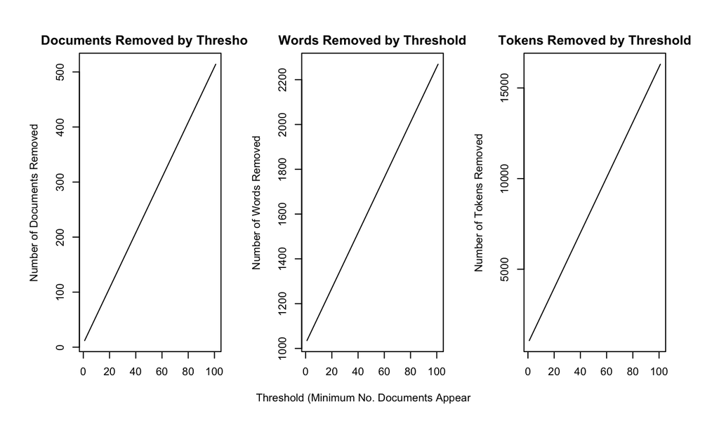

```r
survey.out <- prepDocuments(survey.proc$documents, survey.proc$vocab, survey.proc$meta, lower.thresh=1)
plotRemoved(survey.proc$documents, lower.thresh = seq(1, 200, by = 100))
```

```r
#make a filtered version of the documents based on the ones excluded here:
survey.fulltext.filtered <- surveyFull[c(match(survey.out$meta$id, surveyFull$id)),]$doc
```

### Preprocessing option 2: within **quanteda**

**quanteda** is a commonly used package for reading in and pre-processing data that can be used instead of the **stm** `textProcessor` and `prepDocuments`. Just run quanteda and use the `convert` function to convert to **stm** and a variety of other formats.

```r
library(quanteda)
survey.fullmeta <- data.frame(doc_id=survey.meta$id, survey.meta, shorttext=survey.shorttext, fulltext=survey.fulltext, stringsAsFactors=FALSE)


## create corpus
survey.corpus <- quanteda::corpus(survey.fullmeta, docid_field="doc_id", text_field="fulltext")

##tokenize
toks <- quanteda::tokens(survey.corpus,
                         remove_numbers = TRUE,
                         remove_punct = TRUE,
                         remove_symbols=TRUE) %>%
  quanteda::tokens_remove(stopwords("en")) %>%
  quanteda::tokens_wordstem(language = "en")

toks_ngram <- tokens_ngrams(toks, n = 1)
head(toks_ngram[[6]], 30)

survey.dfm <- dfm(toks_ngram, tolower=TRUE) #%>%
topfeatures(survey.dfm, 20)
```

[output not shown]

```r
survey.dfm <- dfm_trim(survey.dfm, min_docfreq=1, docfreq_type="count")
dim(survey.dfm)

survey.dfm2stm <- quanteda::convert(survey.dfm, to = "stm")
names(survey.dfm2stm)

#make a filtered version of the documents based on the ones excluded here:
survey.fulltext.filtered <- surveyFull[c(match(survey.dfm2stm$meta$id, surveyFull$id)),]$do
```

[output not shown]

## Modeling without metadata structure

The most basic model that can be generated, is like a topic model without structure. It’s very similar to the SAGE (Eisenstein, et al.) sparse estimation of a model with a correlated topic model (CTM) generative process (Blei, et al.).

In this case we will use our `survey.dfm2stm$documents` `survey.dfm2stm$vocab`, `survey.dfm2stm$meta` outputs from quanteda preprocessing for the `documents`, `vocab` (and eventually `meta`) respectively for the stm inputs. Can also use the inputs from the other preprocessing option.

Other notes: Spectral initialization is advised by the authors, and the model should replicate exactly under spectral initialization. One can suppress printed output with `verbose=FALSE`

```r
#preprocessing option 1: stm native option
#documents <- survey.out$documents
#vocab <- survey.out$voc
#meta <- survey.out$meta

#preprocessing option 2: quanteda
documents <- survey.dfm2stm$documents
vocab <- survey.dfm2stm$vocab
meta <- survey.dfm2stm$meta
```

More on the computed metrics here: https://search.r-project.org/CRAN/refmans/stm/html/searchK.html

## Use the model without metadata to examine the model topics (e.g. with wordclouds and findThoughts()) and help choose a reasonable K for using for the STM models with the various metadata covariates.

```r
survey.fit.nometa <- stm(documents = documents,
                     vocab = vocab,
                     K = 15,
                     max.em.its = 100,
                     init.type = "Spectral",
                     verbose = FALSE)
```

### Visualizing the model topics with wordclouds and findThoughts()

```r
library(wordcloud)
stm_for_graph <- survey.fit.nometa
scale <- c(4,.5)
pdf("plots/model_choice/stm_nometa_K15_plot-wordcloud_topic1.pdf")
cloud(stm_for_graph, topic=1, scale=scale)
dev.off()

pdf("plots/model_choice/stm_nometa_K15_plot-wordcloud_topic2.pdf")
cloud(stm_for_graph, topic=2, scale=scale)
dev.off()

pdf("plots/model_choice/stm_nometa_K15_plot-wordcloud_topic3.pdf")
cloud(stm_for_graph, topic=3, scale=scale)
dev.off()

pdf("plots/model_choice/stm_nometa_K15_plot-wordcloud_topic4.pdf")
cloud(stm_for_graph, topic=4, scale=scale)
dev.off()

pdf("plots/model_choice/stm_nometa_K15_plot-wordcloud_topic5.pdf")
cloud(stm_for_graph, topic=5, scale=scale)
dev.off()

pdf("plots/model_choice/stm_nometa_K15_plot-wordcloud_topic6.pdf")
cloud(stm_for_graph, topic=6, scale=scale)
dev.off()

pdf("plots/model_choice/stm_nometa_K15_plot-wordcloud_topic7.pdf")
cloud(stm_for_graph, topic=7, scale=scale)
dev.off()

pdf("plots/model_choice/stm_nometa_K15_plot-wordcloud_topic8.pdf")
cloud(stm_for_graph, topic=8, scale=scale)
dev.off()

pdf("plots/model_choice/stm_nometa_K15_plot-wordcloud_topic9.pdf")
cloud(stm_for_graph, topic=9, scale=scale)
dev.off()

pdf("plots/model_choice/stm_nometa_K15_plot-wordcloud_topic10.pdf")
cloud(stm_for_graph, topic=10, scale=scale)
dev.off()

pdf("plots/model_choice/stm_nometa_K15_plot-wordcloud_topic11.pdf")
cloud(stm_for_graph, topic=11, scale=scale)
dev.off()

pdf("plots/model_choice/stm_nometa_K15_plot-wordcloud_topic12.pdf")
cloud(stm_for_graph, topic=12, scale=scale)
dev.off()

pdf("plots/model_choice/stm_nometa_K15_plot-wordcloud_topic13.pdf")
cloud(stm_for_graph, topic=13, scale=scale)
dev.off()

pdf("plots/model_choice/stm_nometa_K15_plot-wordcloud_topic14.pdf")
cloud(stm_for_graph, topic=14, scale=scale)
dev.off()

pdf("plots/model_choice/stm_nometa_K15_plot-wordcloud_topic15.pdf")
cloud(stm_for_graph, topic=15, scale=scale)
dev.off()

cloud(stm_for_graph, topic=1, scale=scale)
cloud(stm_for_graph, topic=2, scale=scale)
cloud(stm_for_graph, topic=3, scale=scale)
cloud(stm_for_graph, topic=4, scale=scale)
cloud(stm_for_graph, topic=5, scale=scale)
cloud(stm_for_graph, topic=6, scale=scale)
cloud(stm_for_graph, topic=7, scale=scale)
cloud(stm_for_graph, topic=8, scale=scale)
cloud(stm_for_graph, topic=9, scale=scale)
cloud(stm_for_graph, topic=10, scale=scale)
cloud(stm_for_graph, topic=11, scale=scale)
cloud(stm_for_graph, topic=12, scale=scale)
cloud(stm_for_graph, topic=13, scale=scale)
cloud(stm_for_graph, topic=14, scale=scale)
cloud(stm_for_graph, topic=15, scale=scale)
```

[output not shown]

## Estimate the structural topic models (STM) for the chosen K and metadata relevant to each question and survey element of interest

### Summary of models and key covariates:

```r
data <- survey.dfm
out <- survey.dfm2stm

####################################################################
### Fit Models and Make Estimates

# Model 0 - no metadata
survey.fit.nometa <- stm(documents = out$documents,
                         vocab = out$vocab,
                         K = 15, max.em.its = 100,
                         data = out$meta,
                         init.type = "Spectral", verbose = FALSE)

# Model 1 - imce part with frame
survey.fit.frame_part <- stm(out$documents,
                             vocab = out$vocab,
                             K = 15, max.em.its = 100,
                             prevalence =~ imce_Partic + frame,
                             data = out$meta,
                             init.type = "Spectral", verbose=FALSE)

estEff_frame_part <- estimateEffect(
  formula = 1:15 ~ imce_Partic + frame,
  stmobj = survey.fit.frame_part,
  meta = out$meta,
  uncertainty = "Global")

# Model 1 w/ controls:
survey.fit.frame_part_w_controls <- stm(out$documents,
                             vocab = out$vocab,
                             K = 15, max.em.its = 100,
                             prevalence =~ imce_Partic + frame + gender_Male + minority + age + income + education,
                             data = out$meta,
                             init.type = "Spectral", verbose=FALSE)

estEff_frame_part_w_controls <- estimateEffect(
  formula = 1:15 ~ imce_Partic + frame + gender_Male + minority + age + income + education,
  stmobj = survey.fit.frame_part_w_controls,
  meta = out$meta,
  uncertainty = "Global")

# Model 2 - imce densif with pre-frame dens attitude
survey.fit.dens_w_preframe_attitude <- stm(out$documents,
                                           vocab = out$vocab,
                                           K = 15, max.em.its = 100,
                                           prevalence =~ imce_dens + preframe_densifproj_acceptance,
                                           data = out$meta,
                                           init.type = "Spectral", verbose=FALSE)

estEff_dens_w_preframe_attitude <- estimateEffect(
  formula = 1:15 ~ imce_dens + preframe_densifproj_acceptance,
  stmobj = survey.fit.dens_w_preframe_attitude,
  meta = out$meta,
  uncertainty = "Global")

# Model 2 w/ controls
survey.fit.dens_w_preframe_attitude_w_controls <- stm(out$documents,
                                                vocab = out$vocab,
                                                K = 15, max.em.its = 100,
                                                prevalence =~ imce_dens + preframe_densifproj_acceptance + gender_Male + minority + age + income + education + city,
                                                data = out$meta,
                                                init.type = "Spectral", verbose=FALSE)

estEff_dens_w_preframe_attitude_w_controls <- estimateEffect(
  formula = 1:15 ~ imce_dens + preframe_densifproj_acceptance + gender_Male + minority + age + income + education + city,
  stmobj = survey.fit.dens_w_preframe_attitude_w_controls,
  meta = out$meta,
  uncertainty = "Global")

# Model 3 - imce climate with pre-frame climate attitudes
survey.fit.climate_w_attitude <- stm(out$documents,
                                     vocab = out$vocab,
                                     K = 15, max.em.its = 100,
                                     prevalence =~ imce_ClimNeutr + climate_concern,
                                     data = out$meta,
                                     init.type = "Spectral", verbose=FALSE)

estEff_climate <- estimateEffect(
  formula = 1:15 ~ imce_ClimNeutr + climate_concern,
  stmobj = survey.fit.climate_w_attitude,
  meta = out$meta,
  uncertainty = "Global")


# Model 3 w/ controls
survey.fit.climate_w_attitude_w_controls <- stm(out$documents,
                                     vocab = out$vocab,
                                     K = 15, max.em.its = 100,
                                     prevalence =~ imce_ClimNeutr + climate_concern + gender_Male + minority + age + income + education,
                                     data = out$meta,
                                     init.type = "Spectral", verbose=FALSE)

estEff_climate_w_controls <- estimateEffect(
  formula = 1:15 ~ imce_ClimNeutr + climate_concern + gender_Male + minority + age + income + education,
  stmobj = survey.fit.climate_w_attitude_w_controls,
  meta = out$meta,
  uncertainty = "Global")


# Model 4 - imce rent control and zoning with political affiliation
survey.fit.rentc_zone_pol <- stm(out$documents,
                                 vocab = out$vocab,
                                 K = 15, max.em.its = 100,
                                 prevalence =~ imce_RentContr + imce_InclZon + political_left_right,
                                 data = out$meta,
                                 init.type = "Spectral", verbose=FALSE)


estEff_rentc_zone_pol <- estimateEffect(
  formula = 1:15 ~ imce_RentContr + imce_InclZon + political_left_right,
  stmobj = survey.fit.rentc_zone_pol,
  meta = out$meta,
  uncertainty = "Global")

# Model 4 w/ controls
survey.fit.rentc_zone_pol_w_controls <- stm(out$documents,
                                 vocab = out$vocab,
                                 K = 15, max.em.its = 100,
                                 prevalence =~ imce_RentContr + imce_InclZon + political_left_right + gender_Male + minority + age + income + education,
                                 data = out$meta,
                                 init.type = "Spectral", verbose=FALSE)


estEff_rentc_zone_pol_w_controls <- estimateEffect(
  formula = 1:15 ~ imce_RentContr + imce_InclZon + political_left_right + gender_Male + minority + age + income + education,
  stmobj = survey.fit.rentc_zone_pol_w_controls,
  meta = out$meta,
  uncertainty = "Global")

# Model 5 w/ controls - imce rent control and zoning with minority and controls
survey.fit.rentc_zone_minority_w_context_w_controls <- stm(out$documents,
                                                           vocab = out$vocab,
                                                           K = 15, max.em.its = 100,
                                                           prevalence =~ imce_RentContr + imce_InclZon + gender_Male + minority + age + income + education,
                                                           content =~ minority,
                                                           data = out$meta,
                                                           init.type = "Spectral", verbose=FALSE)


estEff_rentc_zone_minority_w_context_w_controls <- estimateEffect(
  formula = 1:15 ~ imce_RentContr + imce_InclZon + gender_Male + minority + age + income + education,
  stmobj = survey.fit.rentc_zone_minority_w_context_w_controls,
  meta = out$meta,
  uncertainty = "Global")

# Model 6 w/ controls - imce rent control and zoning with controls and city (will also include if they have seen_landlord_pressure and if they fear being forced out)
survey.fit.rentc_zone_city_w_context_w_controls <- stm(out$documents,
                                                           vocab = out$vocab,
                                                           K = 15, max.em.its = 100,
                                                           prevalence =~ imce_RentContr + imce_InclZon + seen_landlord_pressure + fear_forced_out
                                                              + city + gender_Male + minority + age + income + education,
                                                           content =~ city,
                                                           data = out$meta,
                                                           init.type = "Spectral", verbose=FALSE)


estEff_rentc_zone_city_w_context_w_controls <- estimateEffect(
  formula = 1:15 ~ imce_RentContr + imce_InclZon + seen_landlord_pressure + fear_forced_out
  + city + gender_Male + minority + age + income + education,
  stmobj = survey.fit.rentc_zone_city_w_context_w_controls,
  meta = out$meta,
  uncertainty = "Global")


# Model 2 w/ controls and city content modifier
survey.fit.dens_w_preframe_attitude_w_controls_inc_city_content <- stm(out$documents,
                                                      vocab = out$vocab,
                                                      K = 15, max.em.its = 100,
                                                      prevalence =~ imce_dens + preframe_densifproj_acceptance + gender_Male + minority + age + income + education + city,
                                                      content =~ city,
                                                      data = out$meta,
                                                      init.type = "Spectral", verbose=FALSE)


estEff_dens_w_preframe_attitude_w_controls_inc_city_content <- estimateEffect(
  formula = 1:15 ~ imce_dens + preframe_densifproj_acceptance + gender_Male + minority + age + income + education + city,
  stmobj = survey.fit.dens_w_preframe_attitude_w_controls_inc_city_content,
  meta = out$meta,
  uncertainty = "Global")
```

## Write the STM models and effect estimates to an Rdata file for examination with stminsights and other visualizations

```r
# save objects in .RData file
save.image('stm_models_dens_survey_paper_final_2022.RData')
```